# Tipos de filmes

Nazareno

16/04/2017

```r
library(tidyverse, warn.conflicts = F)
library(rvest)
library(plotly)
library(cluster)
library(ggdendro)
theme_set(theme_light())
source("plota_solucoes_hclust.R")
```

Usaremos dados do [Rotten Tomatoes](https://www.rottentomatoes.com) sobre os filmes de Scarlett Johansson.

```r
from_page <- read_html("https://www.rottentomatoes.com/celebrity/scarlett_johansson/") %>%
    html_node("#filmographyTbl") %>% # A sintaxe da expressão é de um seletor à lá JQuery
    html_table(fill=TRUE) %>% # Faz parse
    as.tibble()
filmes = from_page %>%
    filter(RATING != "No Score Yet",
           `BOX OFFICE` != "—",
           CREDIT != "Executive Producer") %>%
    mutate(RATING = as.numeric(gsub("%", "", RATING)),
           `BOX OFFICE` = as.numeric(gsub("[$|M]", "", `BOX OFFICE`))) %>%
    filter(`BOX OFFICE` >= 1) # Tem dois filmes que não parecem ter sido lançados no mundo todo
```

```
NAs introduzidos por coerção
```

## A intuição

Uma forma de descrever estrutura nos dados é percebendo grupos de observações mais semelhantes entre si que com o restante dos dados. Agrupamentos.

Por exemplo, observando as avaliações dos filmes:

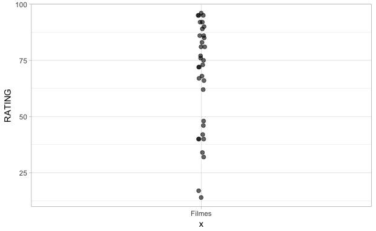

```r
filmes %>%
    ggplot(aes(x = "Filmes", y = RATING)) +
    geom_jitter(width = .01, height = 0, size = 2, alpha = .6)
```

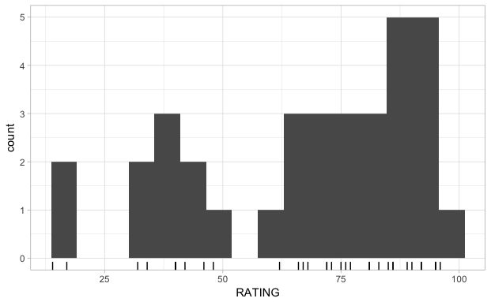

```r
filmes %>%
    ggplot(aes(x = RATING)) +
    geom_histogram(bins = 16) +
    geom_rug()
```

Já considerando o ano de lançamento, não há uma estrutura clara de grupos.

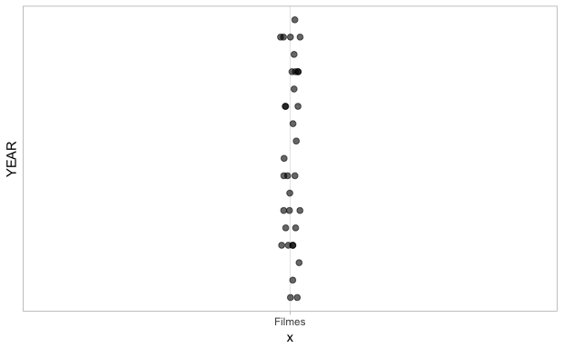

```r
filmes %>%
    ggplot(aes(x = "Filmes", y = YEAR)) +
    geom_jitter(width = .02, height = 0, size = 2, alpha = .6) +
    scale_y_log10()
```

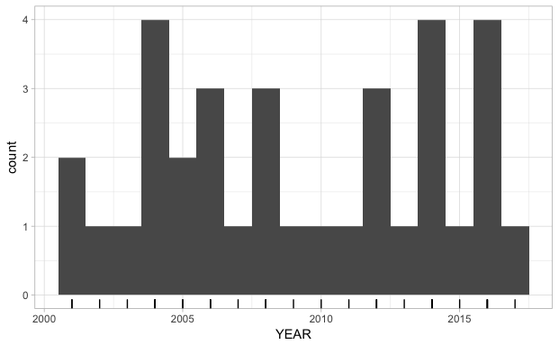

```r
filmes %>%
    ggplot(aes(x = `YEAR`)) +
    geom_histogram(bins = 17) +
    geom_rug()
```

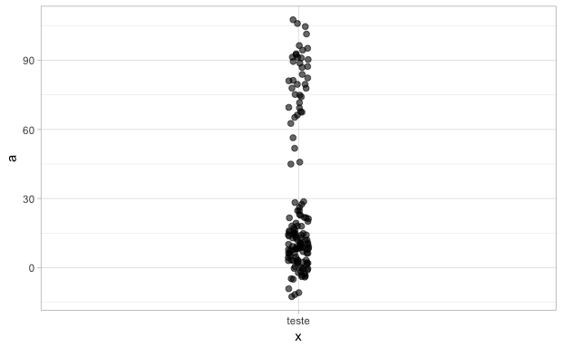

```r
tibble(a = c(rnorm(100, mean = 10, sd = 10),
             rnorm(40, mean = 80, sd = 15))) %>%
    ggplot(aes(x = "teste", y = a)) +
    geom_jitter(width = .02, height = 0, size = 2, alpha = .6)
```

Para a renda do filme, observar uma escala linear ou logarítmica levam a conclusões diferentes.

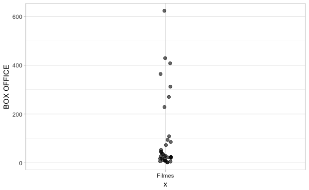

```r
filmes %>%
    ggplot(aes(x = "Filmes", y = `BOX OFFICE`)) +
    geom_jitter(width = .02, height = 0, size = 2, alpha = .6)
```

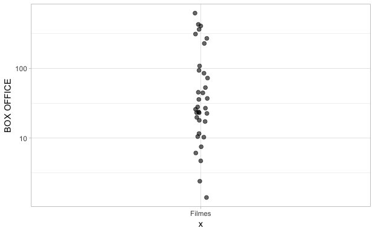

```r
filmes %>%
    ggplot(aes(x = "Filmes", y = `BOX OFFICE`)) +
    geom_jitter(width = .02, height = 0, size = 2, alpha = .6) +
    scale_y_log10()
```

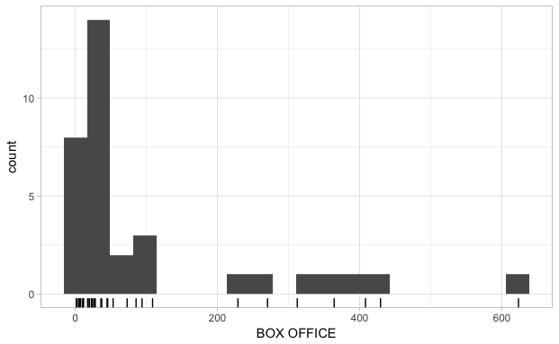

```r
filmes %>%
    ggplot(aes(x = `BOX OFFICE`)) +
    geom_histogram(bins = 20) +
    geom_rug()
```

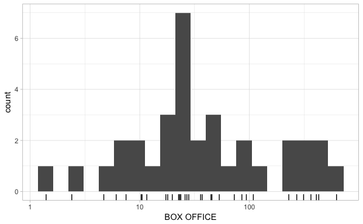

```r
filmes %>%
    ggplot(aes(x = `BOX OFFICE`)) +
    geom_histogram(bins = 20) +
    scale_x_log10() +
    geom_rug()
```

## Agrupamento

Precisamos de:

- Definição de proximidade/distância entre pontos
- Definição de proximidade/distância entre grupos ou grupos e pontos
- Processo de agrupamento
- Decidir quantos grupos existem

Para produzir uma solução de agrupamento. Depois vem o principal: **avaliar e interpretar** a solução. *Agrupamento sempre dá um resultado. Nem sempre é útil*.

## Com uma dimensão

Há duas maneiras principais de agrupar: aglomerativa ou baseada em partição. Vamos explorar primeiro a **hierárquica aglomerativa**.

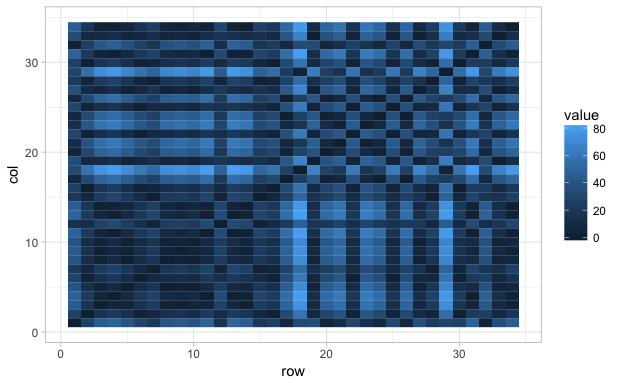

```r
distancias.long = filmes %>%
    select(RATING) %>%
    dist(method = "euclidean") %>%
    as.matrix %>%
    reshape2::melt(varnames = c("row", "col"))
distancias.long %>%
    ggplot(aes(x = row, y = col, fill = value)) +
    geom_tile()
```

```r
# distancias = filmes %>%
#     select(RATING) %>%
#     dist(method = "euclidean") %>%
#     as.matrix %>%
#     heatmap()
```

```r
row.names(filmes) = NULL
agrupamento_h = filmes %>%
    column_to_rownames("TITLE") %>% # hclust precisa dos rótulos em nomes de linha (ruim)
    select(RATING) %>%
    dist(method = "euclidean") %>%
    hclust(method = "complete")
```

```
Setting row names on a tibble is deprecated.
```

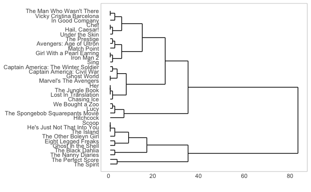

```r
ggdendrogram(agrupamento_h, rotate = T, size = 2)
```

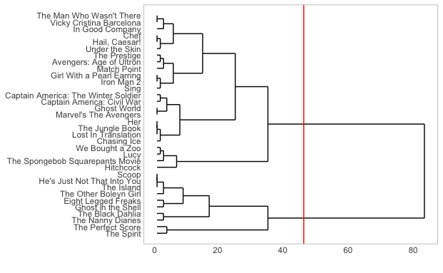

```r
ggdendrogram(agrupamento_h, rotate = T, size = 2) +
    geom_hline(yintercept = 45, colour = "red")
```

Cada junção é um passo do algoritmo. A altura na dendrograma em cada passo significa a dissimilaridade entre os pontos ou grupos juntados naquele passo.

Na medida que vamos aglomerando, as dissimilaridades nas junções tendem a ir aumentando caso haja estrutura de grupos.

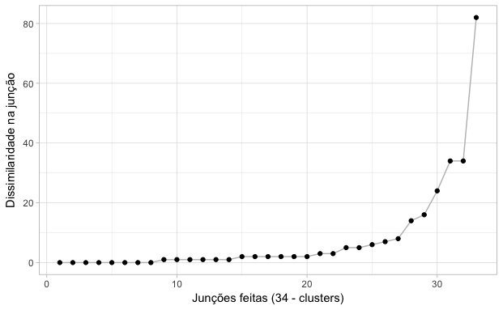

```r
data.frame(k = 1:NROW(agrupamento_h$height),
           height = agrupamento_h$height) %>%
    ggplot(aes(x = k, y = height)) +
    geom_line(colour = "grey") +
    geom_point() +
    labs(x = "Junções feitas (34 - clusters)", y = "Dissimilaridade na junção")
```

Vejamos as soluções com diferentes números de grupos.

```r
solucoes = tibble(k = 1:9)
atribuicoes = solucoes %>%
    group_by(k) %>%
    do(cbind(filmes,
             grupo = as.character(cutree(agrupamento_h, .$k))))
```

```
Unequal factor levels: coercing to character
```

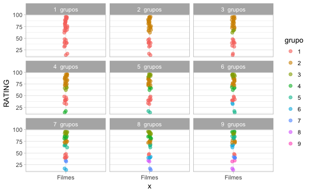

```r
atribuicoes %>%
    ggplot(aes(x = "Filmes", y = RATING, colour = grupo)) +
    geom_jitter(width = .02, height = 0, size = 2, alpha = .6) +
    facet_wrap(~ paste(k, " grupos"))
```

`stats::heatmap()` é uma função que visualiza distâncias entre pontos organizando linhas e colunas via `hclust`:

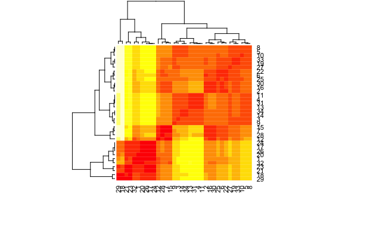

```r
filmes %>%
    select(RATING) %>%
    dist(method = "euclidean") %>%
    as.matrix %>%
    heatmap()
```

### Variando o método de linkage

```
Setting row names on a tibble is deprecated.Unequal factor levels: coercing to character
```

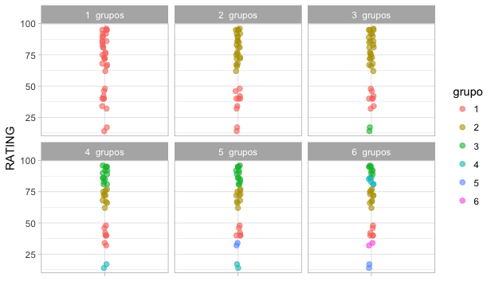

```r
plota_hclusts_1d(filmes, "RATING",
                 linkage_method = "centroid", # single, complete, average, centroid, median, ...
                 ks = 1:6)
```

```r
names(iris)
```

```
[1] "Sepal.Length" "Sepal.Width"  "Petal.Length" "Petal.Width"  "Species"
```

### Com outras variáveis

Agrupamento sempre dá um resultado. Mesmo quando ele não é útil:

```
Setting row names on a tibble is deprecated.Unequal factor levels: coercing to character
```

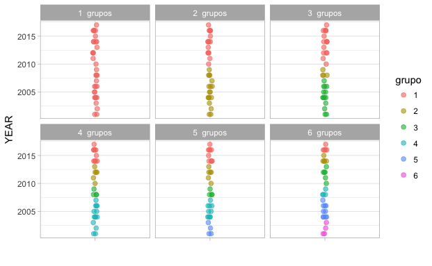

```r
plota_hclusts_1d(filmes, "YEAR", linkage_method = "centroid", ks = 1:6)
```

Compare as soluções usando a escala linear da variável e a transformada em log:

```
Setting row names on a tibble is deprecated.Unequal factor levels: coercing to character
```

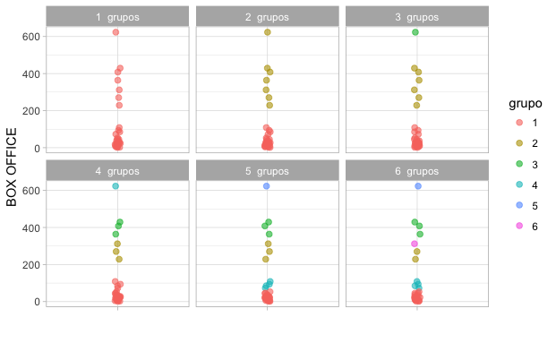

```r
plota_hclusts_1d(filmes, "`BOX OFFICE`", linkage_method = "centroid", ks = 1:6)
```

```
Setting row names on a tibble is deprecated.Unequal factor levels: coercing to character
```

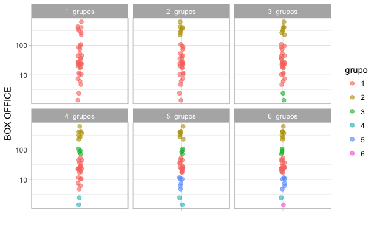

```r
filmes %>% mutate(`BOX OFFICE` = log(`BOX OFFICE`)) %>%
    plota_hclusts_1d("`BOX OFFICE`", linkage_method = "centroid", ks = 1:6) +
    scale_y_log10()
```

## Silhouetas

Dada a distância média de um ponto para os demais do seu cluster $a(i)$ e a distância média do ponto para todos os demais do cluster mais próximo $b(i)$, a largura da silhoueta de $i$ é :

$$s(i) := ( b(i) - a(i) ) / max( a(i), b(i) )$$

Repare como 1 significa uma boa atribuição para $i$, 0 significa indefinição e $-1$ significa que há outro cluster onde $i$ estaria melhor alocado.

```r
distancias = filmes %>%
    select(RATING) %>%
    dist(method = "euclidean")
agrupamento_hs = filmes %>%
    column_to_rownames("TITLE") %>%
    select(RATING) %>%
    dist(method = "euclidean") %>%
    hclust(method = "complete")
```

```
Setting row names on a tibble is deprecated.
```

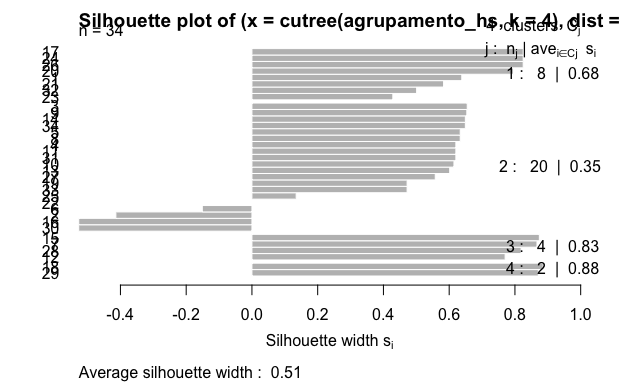

```r
plot(silhouette(cutree(agrupamento_hs, k = 4), distancias))
```

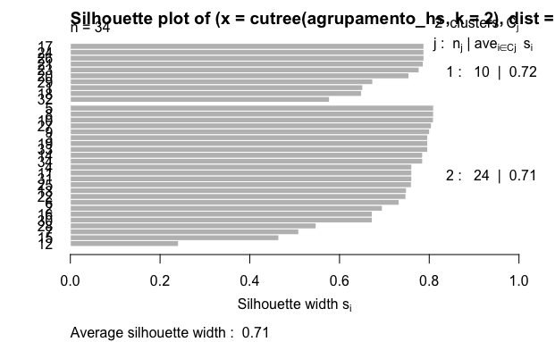

```r
plot(silhouette(cutree(agrupamento_hs, k = 2), distancias))
```

## Duas dimensões

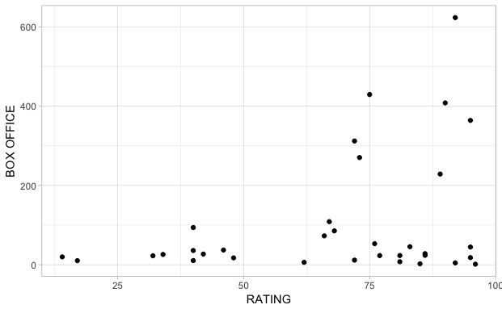

```r
p = filmes %>%
    ggplot(aes(x = RATING, y = `BOX OFFICE`, label = TITLE)) +
    geom_point()
p
```

```r
#ggplotly(p)
```

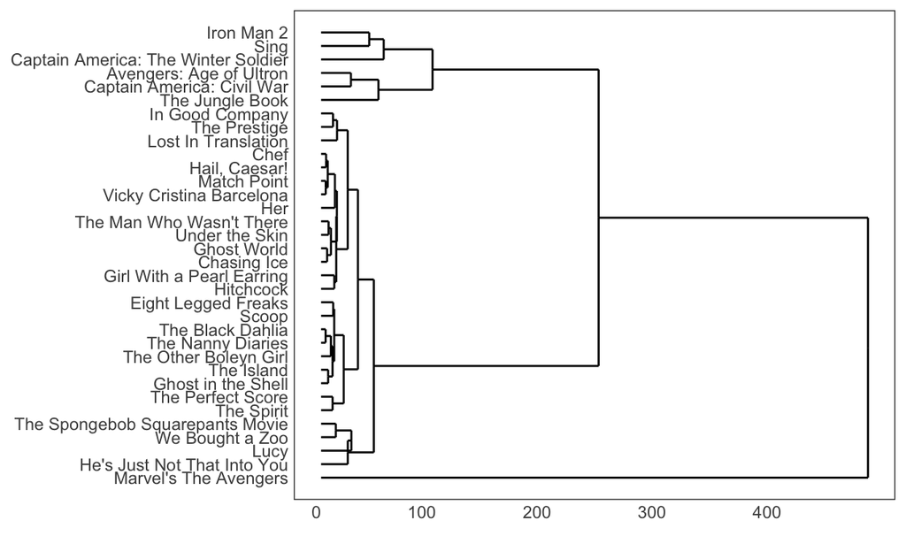

Como sempre, o algoritmo encontra grupos. No caso, parecem até bem separados. Vamos visualizá-los:

```
Unequal factor levels: coercing to character
```

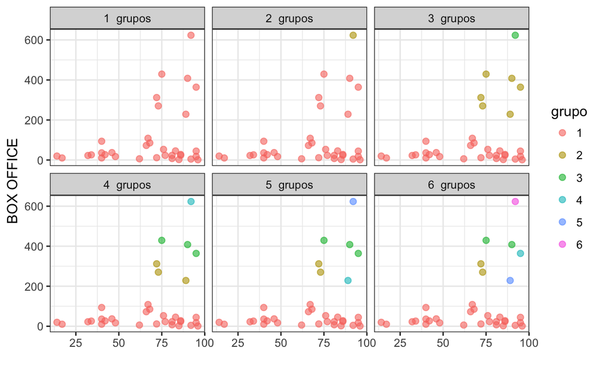

```r
plota_hclusts_2d(agrupamento_h_2d,
                 filmes,
                 c("RATING", "`BOX OFFICE`"),
                 linkage_method = "centroid", ks = 1:6)
```

O agrupamento está acontecendo todo em função de BOX OFFICE, apenas. Como as escalas são diferentes, BOX OFFICE domina qualquer cálculo de distância euclidiana.

Solução: standardize (aka scale).

```r
agrupamento_h_2d = filmes %>%
    column_to_rownames("TITLE") %>%
    select(RATING, `BOX OFFICE`) %>%
    mutate(`BOX OFFICE` = log10(`BOX OFFICE`)) %>%
    mutate_all(funs(scale)) %>%
    dist(method = "euclidean") %>%
    hclust(method = "ward.D")
```

```
Setting row names on a tibble is deprecated.
```

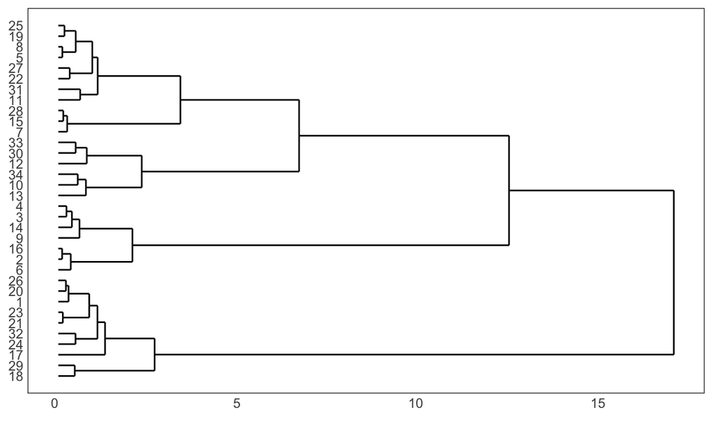

```r
ggdendrogram(agrupamento_h_2d, rotate = TRUE)
```

```
Unequal factor levels: coercing to character
```

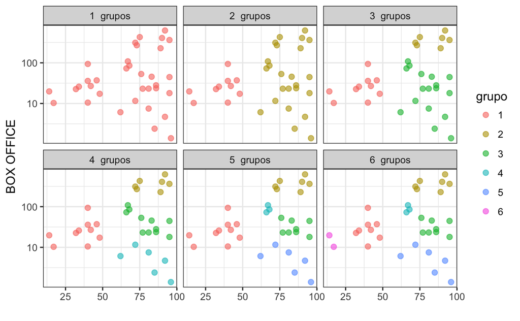

```r
filmes2 = filmes %>% mutate(`BOX OFFICE` = log10(`BOX OFFICE`))
plota_hclusts_2d(agrupamento_h_2d,
                 filmes2,
                 c("RATING", "`BOX OFFICE`"),
                 linkage_method = "ward.D", ks = 1:6) + scale_y_log10()
```

## Mais variáveis

E se tivéssemos mais de duas variáveis?

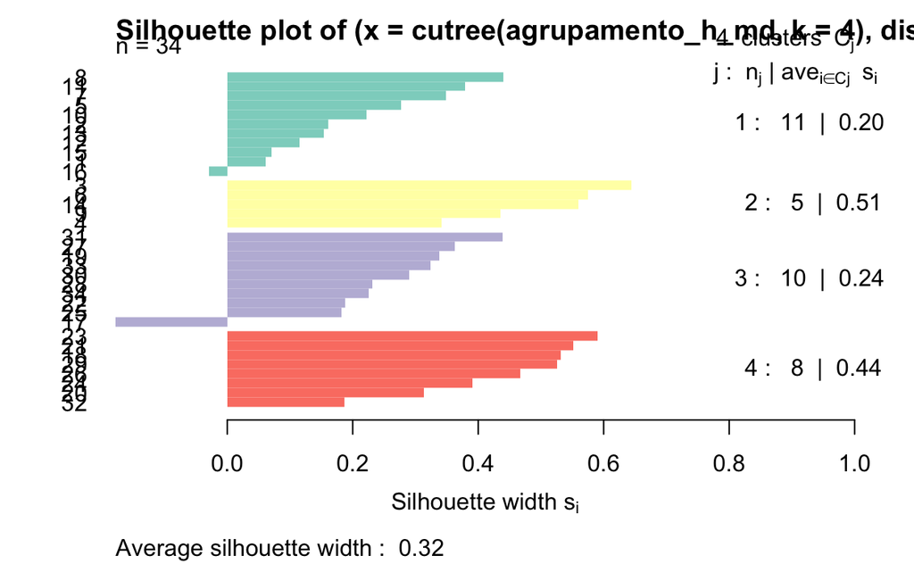

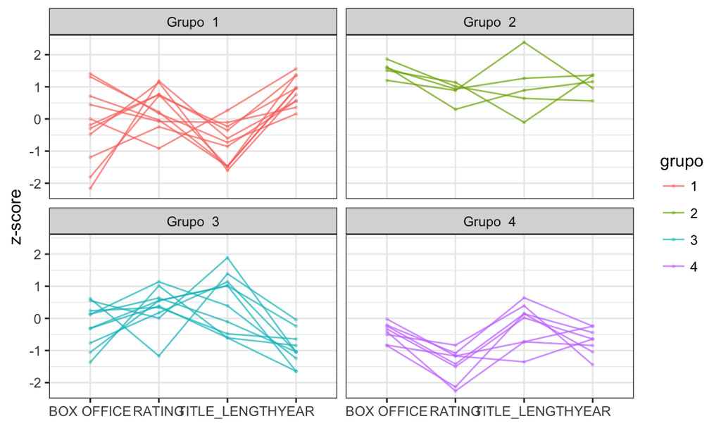